# Power and data simulation

Dorothy Bishop

September 2018

## Learning Objectives

Overarching aim: work with simulated data to get a deeper understanding of key statistical concepts.  
Specifically:

- Understand basic idea of how data simulation works
- Understand why it is a good idea to simulate data for your own studies before you collect real data
- See how simulated random data can help understand what p-hacking is and why it is a problem
- See how to simulate data with real effects to illustrate problems with low power in small sample sizes

## Pre-workshop preparation (*optional*)

The workshop will illustrate data simulation in Excel and R.  
In a large lecture theatre it won’t be possible to work interactively with the audience, and it is fine if you prefer just to listen and learn and then try out some of the exercises which will be available online later.

However, if you would like to bring a laptop with you, you are welcome to try to work along as examples are illustrated. The initial examples will not require anything other than a laptop with Excel.

Later examples will illustrate the benefits of using the R programming language. Don’t worry if you are not familiar with R: the exercises will give you a taster and they do not assume prior experience. There are some suggestions for familiarising yourself with the basics below, but you should be able to benefit from the lecture, even if you are a total novice.

People who are not familiar with R, who would like to try to work along with the exercises will need to do some preparation in advance, by installing R and R studio (instructions below). Those already familiar with R should install the packages listed below.

### 1. Install R (free software)

- Open an internet browser and go to www.r-project.org.
- Click the “download R” link in the middle of the page under “Getting Started.”
- Click on the link for a CRAN location close to you
- **Mac users**:
  - Click on the “Download R for (Mac) OS X” link at the top of the page.
  - Click on the file containing the latest version of R under “Files.”
  - Save the .pkg file, double-click it to open, and follow the installation instructions.
- **Windows users**:
  - Click on the “Download R for Windows” link at the top of the page.
  - Click on the “install R for the first time” link at the top of the page.
  - Click “Download R for Windows” and save the executable file somewhere on your computer.
  - Run the .exe file and follow the installation instructions.

### 2. Install R studio - a friendly interface for R

- Go to www.rstudio.com and click on the “Download RStudio” button.
- Click on “Download RStudio Desktop.”
- **Mac users**:
  - Click on the version recommended for your system, or the latest Mac version, save the .dmg file on your computer, double-click it to open, and then drag and drop it to your applications folder.
- **Windows users**:
  - Click on the version recommended for your system, or the latest Windows version, and save the executable file. Run the .exe file and follow the installation instructions.

Once R studio is installed, you need not open the original R software: instead, you access R by opening the R studio application.

### 3. Install packages

- Open R studio
- On the menu bar at the top, select **Tools > Install Packages**

[figure not shown]

Install packages tool in RStudio

For this workshop, we use three packages. You can select these by typing the name in the box that pops up, and then selecting Install after selecting the one you want. The packages are `MASS`, `HMisc` and `yarrr` (Note that `yarrr` has three Rs!)

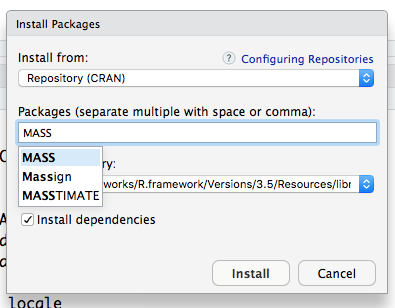

Install packages dialogue in RStudio

`MASS` is used for generating multivariate normal random numbers (among other things), `HMisc` is useful for computing correlations, and `yarrr` is used to create a nice kind of plot called a pirate plot.  
For each one you install, you will see text flashing by on your console as it is loaded.

Just last week, a nice package was published for doing and visualising correlations, called `corrr` (again 3 Rs!). If you are an R expert and want a challenge beyond the elementary content of the exercises, you could install that as well and see what it can do.

### 4. Upload some introductory scripts

From the Open Science Framework site, https://osf.io/skz3j/, download these scripts and save on a folder that you will use for work in R:

- [Simulation_ex1_intro.R](https://osf.io/dhw9u/)
- [Simulation_ex1_multioutput.R](https://osf.io/m3f2d/)
- [Simulation_ex2_correlations.R](https://osf.io/wt2uy/)

## R for total novices

- A very friendly and basic interface for learning R is here: https://swirlstats.com/
- There are various online courses on R from Data Carpentry and Software Carpentry that you can find by Googling: these are geared to different disciplines, and you may find it helpful to browse to find one most suited to your field. This one, although designated for Social Sciences, is a good introduction to the `tidyverse` - a set of functions in R that make data manipulation relatively easy: https://datacarpentry.org/r-socialsci/. It also has a good first lesson to just help you find your way around R studio.

I’m always interested to hear of other free online resources that people find helpful, so let me know if you have any recommendations.

*Transcription: Matt Jaquiery*